# Programmation Statistique : Contrôle Continu 1

Chaque exercice est accompagné d’un script R. Vous compléterez le script, et répondrez aux questions via les commentaires au sein du script. Les trois scripts (un pour chaque exercice) sont à déposer sur Moodle avant le temps imparti.

**Important**

Téléchargez les scripts et placez les dans un dossier “CC1”.

**Prenez ce dossier comme répertoire de travail R.**

## Exercice 1

**Note**

*Cet exercice propose d’implémenter quelques méthodes permettant de simuler des tirages aléatoires de lois connues, simplement par transformation de tirages i.i.d d’une loi uniforme.*

### Méthode de la transformée inverse

1. Codez une fonction `F_inv` qui, à un réel $x \in \mathbb{R}$ associe $-\frac{\ln(1-x)}{0.5}$.

   ```r
   F_inv <- function(x) - log(1-x)/0.5
   ```

2. Effectuez $N=1000$ tirages selon la loi $\mathcal{U}([0,1])$, stockez ces tirages dans un vecteur `a`, puis créer le vecteur `r` tel que $r_i = F_{\mathrm{inv}}(a_i), \quad \forall i=1,2,\dots,N$.

   ```r
   N <- 1000
   a <- runif(n=N)
   r <- F_inv(a)
   df <- data.frame(a = a, r = r)
   ```

3. Affichez l’histogramme (normalisé) du vecteur `r`. *Bonus : Superposez-y la densité d’une loi bien connue.*

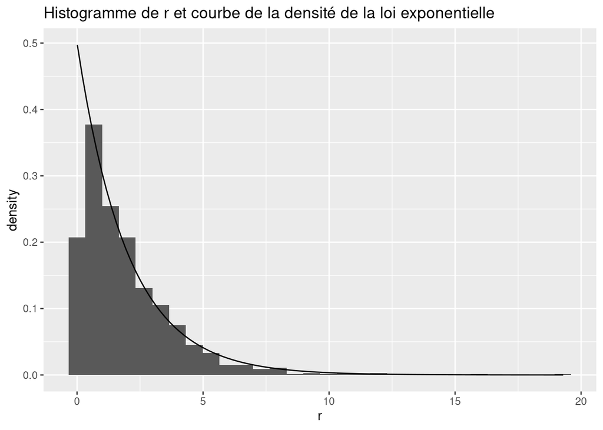

   ```r
   library(ggplot2)
   ggplot(df) +
     geom_histogram(mapping=  aes(x=r, after_stat(density))) +
     stat_function(fun =dexp, args = list(rate=0.5)) +
     labs(title="Histogramme de r et courbe de la densité de la loi exponentielle")
   ```

### Box-Muller 1

1. Effectuez $N=1000$ tirages selon la loi $\mathcal{U}([0,2\pi])$, stockez ces tirages dans un vecteur $\theta$ (`theta`), puis posez :

$$x_i = \sqrt{r_i} \cos(\theta_i), \quad y_i = \sqrt{r_i} \sin(\theta_i)$$

```r
library(tidyverse)
df <- mutate(df,
             theta = runif(n=N, min=0, max=2*pi),
               x = sqrt(r)*cos(theta),
               y = sqrt(r)*sin(theta)
)
```

2. Affichez l’histogramme (normalisé) du vecteur `x` obtenu. *Bonus : Superposez-y la densité d’une loi bien connue.*

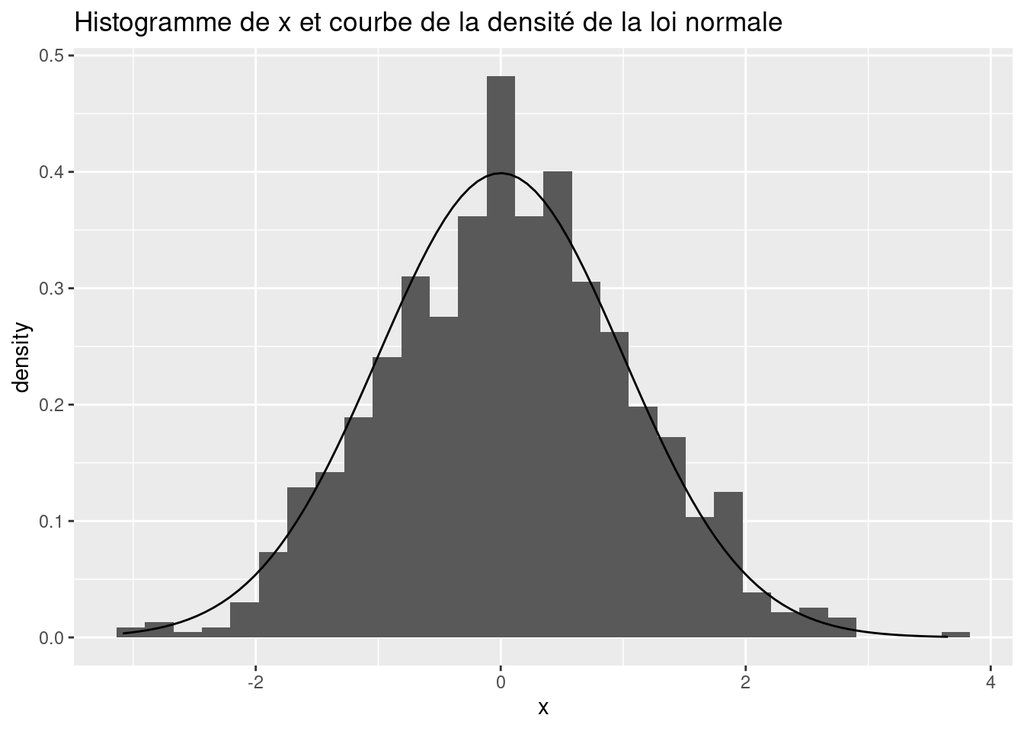

   ```r
   ggplot(df) +
     geom_histogram(mapping=  aes(x=x, after_stat(density))) +
     stat_function(fun =dnorm) +
     labs(title="Histogramme de x et courbe de la densité de la loi normale")
   ```

3. Calculez la corrélation empirique entre `x` et `y`. On admet que `x` est un vecteur des réalisations d’une loi $\mathcal{N}(0,1)$. Comment obtenir, à partir des réalisations `x` de $X$, des réalisations d’une loi $\mathcal{N}(2, 4)$ ?

```r
# Corrélation empirique :
cor(df$x,df$y)
```

```
[1] 8.149582e-05
```

```r
# Réalisation de N(2,4) :
# par transformation affine :
z <- 2*df$x+2
```

### Box-Muller 2

1. Ajoutez au tableau `df` les variables :
   - $\tilde{r}$ (noté `r_tilde`) : $N$ réalisations d’une loi uniforme sur $[0,1]$,
   - $\tilde{x}$ (noté `x_tilde`) où $\tilde{x} = \sqrt{\tilde{r}}*\cos(\theta)$,
   - $\tilde{y}$ (noté `y_tilde`) où $\tilde{y} = \sqrt{\tilde{r}}*\sin(\theta)$.

Tracez le nuage de points obtenu avec `x_tilde` et `y_tilde`. On pourra ajouter la commande `coord_equal()` au graphique `ggplot` afin d’avoir une échelle identique pour les axes des abscisses et ordonnées.

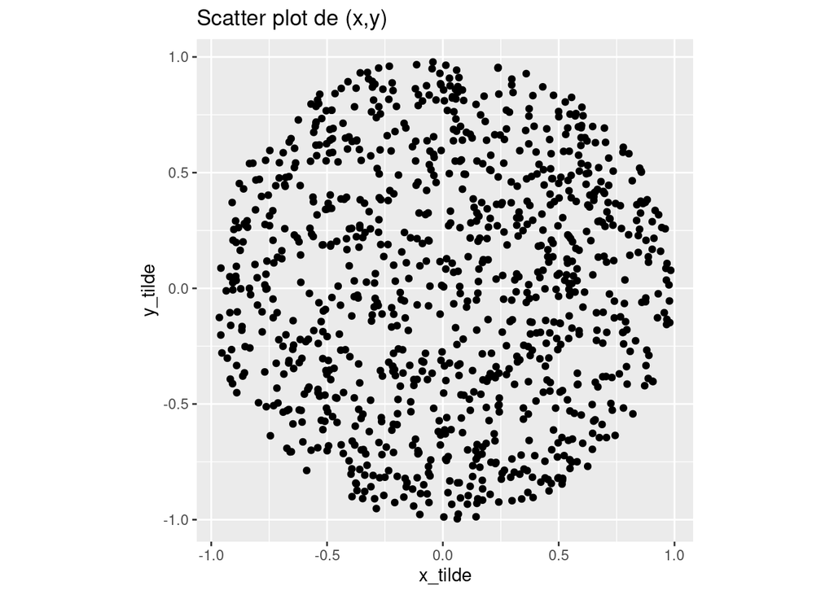

```r
df <- mutate(df,
             r_tilde = runif(n=N),
             x_tilde = sqrt(r_tilde)*cos(theta),
             y_tilde = sqrt(r_tilde)*sin(theta)
)

# Graphique :
ggplot(df) + aes(x=x_tilde, y = y_tilde) +
  geom_point() +
  labs(title="Scatter plot de (x,y)") +
  coord_equal()
```

2. On admet que les couples $(\tilde{x}_i, \tilde{y}_i)$ sont des réalisations i.i.d du vecteur aléatoire $(\tilde{X}, \tilde{Y})$ suivant une loi uniforme sur le **disque** de $\mathbb{R}^2$ de rayon $1$. Selon vous, comment, à partir des réalisations `x_tilde`, `y_tilde` de $(\tilde{X}, \tilde{Y})$, obtenir des réalisations d’une loi uniforme sur le **cercle** de rayon $1$ ? Tracez le nuage de point correspondant.

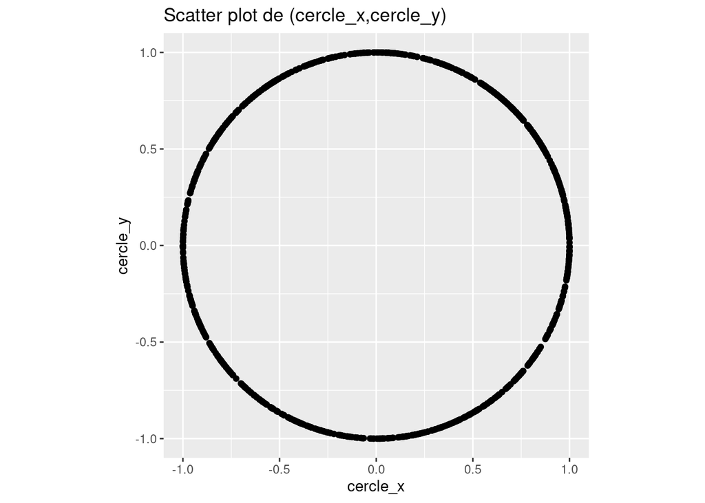

   ```r
   df <- mutate(df,
                cercle_x = x_tilde/sqrt(r_tilde),
                cercle_y = y_tilde/sqrt(r_tilde)
   )

   # Graphique :
   ggplot(df) + aes(x=cercle_x, y = cercle_y) +
     geom_point() +
     labs(title="Scatter plot de (cercle_x,cercle_y)") +
     coord_equal()
   ```

## Exercice 2

### Import et gestion de tableau

1. Importez le *package* `tidyverse` et prenez connaissance des données `diamonds`. Combien d’observations ? Combien de variables, et de quelles natures ?

   ```r
   rm(list=ls())
   # Import
   library(tidyverse)
   str(diamonds)
   ```

   ```
   tibble [53,940 × 10] (S3: tbl_df/tbl/data.frame)
    $ carat  : num [1:53940] 0.23 0.21 0.23 0.29 0.31 0.24 0.24 0.26 0.22 0.23 ...
    $ cut    : Ord.factor w/ 5 levels "Fair"<"Good"<..: 5 4 2 4 2 3 3 3 1 3 ...
    $ color  : Ord.factor w/ 7 levels "D"<"E"<"F"<"G"<..: 2 2 2 6 7 7 6 5 2 5 ...
    $ clarity: Ord.factor w/ 8 levels "I1"<"SI2"<"SI1"<..: 2 3 5 4 2 6 7 3 4 5 ...
    $ depth  : num [1:53940] 61.5 59.8 56.9 62.4 63.3 62.8 62.3 61.9 65.1 59.4 ...
    $ table  : num [1:53940] 55 61 65 58 58 57 57 55 61 61 ...
    $ price  : int [1:53940] 326 326 327 334 335 336 336 337 337 338 ...
    $ x      : num [1:53940] 3.95 3.89 4.05 4.2 4.34 3.94 3.95 4.07 3.87 4 ...
    $ y      : num [1:53940] 3.98 3.84 4.07 4.23 4.35 3.96 3.98 4.11 3.78 4.05 ...
    $ z      : num [1:53940] 2.43 2.31 2.31 2.63 2.75 2.48 2.47 2.53 2.49 2.39 ...
   ```

   *Réponse : 53 940 observations de 10 variables. Les variables `cut`, `color` et `clarity` sont des variables qualitatives ordinales. Les autres variables sont quantitatives.*
2. Sélectionnez dans le *data-frame* `diamonds` les diamants dont le carat est supérieur à 0.5, la coupe égale à `"Premium"` et la couleur égale à `"D"`. Conservez uniquement les colonnes `carat` et `price`, et renommer la colonne `price` en `prix`.

   ```r
   diamonds %>%
     filter(carat>0.5 & cut == "Premium" & color =="D") %>%
     select(carat, price) %>%
     rename(prix = price)
   ```

   ```
   # A tibble: 971 × 2
      carat  prix
      <dbl> <int>
    1  0.71  2768
    2  0.71  2770
    3  0.7   2773
    4  0.72  2782
    5  0.7   2782
    6  0.72  2795
    7  0.71  2797
    8  0.71  2797
    9  0.71  2797
   10  0.81  2809
   # ℹ 961 more rows
   ```

```r
# Copie
diamants <- diamonds

# Transformations
diamants %<>%
  mutate(x = 0.1*x, y = 0.1*y, z=0.1*z, carat= 0.2*carat) %>%
  rename(longueur=x, largeur=y, profondeur=z, masse = carat) %>%
  mutate(volume = longueur*largeur*profondeur/3)
```

### Transformation du tableau, visualisation *outliers*

1. À partir de `diamants`, créez un tableau `diamants_long` pour passer d’un format *large* au format *long*. Dans ce nouveau tableau :
   - les **valeurs** des variables `longueur`, `largeur`, `profondeur` figurent dans une seule colonne appelée `distance`,
   - le **nom** correspondant (`longueur`, `largeur` ou `profondeur`) dans une colonne `dimension` .
   - les autres colonnes restent inchangées.

Ainsi, un diamant apparaîtra sur trois lignes de ce nouveau tableau, une fois pour chaque `dimension` : `longueur`, `largeur` et `profondeur`.

*Indication : Ce nouveau tableau possède plus de lignes et moins de colonnes que le tableau d’origine.*

```r
diamants_long <- pivot_longer(diamants, cols = c(longueur, largeur, profondeur),
                              names_to = "dimension",
                              values_to = "distance")
```

**Important**

**Si vous n’avez pas réussi à créer `diamants_long`, dé-commenter la ligne d’import**

**du fichier `diamants_long` dans le script `Exercice2`.**

2. Sur une même fenêtre graphique, affichez les boites à moustache des variables `longueur`, `largeur` et `profondeur`.

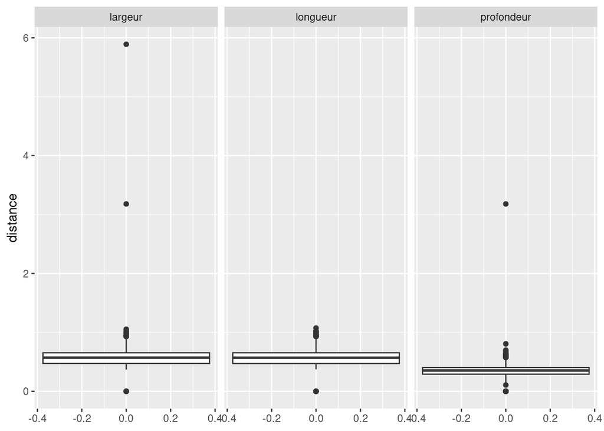

   ```r
   # Graphique :
   ggplot(diamants_long) +
     aes(y=distance)+
     geom_boxplot()+
     facet_grid(~dimension)
   ```

3. A partir du tableau `diamants`, créer un tableau `diamants_bis` où vous retirerez les observations ayant :
   - un volume inférieur ou égal à zéro
   - une largeur ou une profondeur supérieur à 2cm.

   ```r
   diamants_bis <- diamants %>%
     filter(volume > 0 & largeur < 2 & profondeur < 2)
   ```

### Affichage et lien `masse` <-> `volume`

**Important**

**On utilise ici les données traitées `diamants_bis`. Si vous n’avez pas réussi à créer `diamants_bis`, dé-commenter la ligne d’import du fichier `diamants_bis` dans le script `Exercice2`.**

1. Affichez le nuage de points obtenu avec le volume en abscisse et la masse en ordonnée.

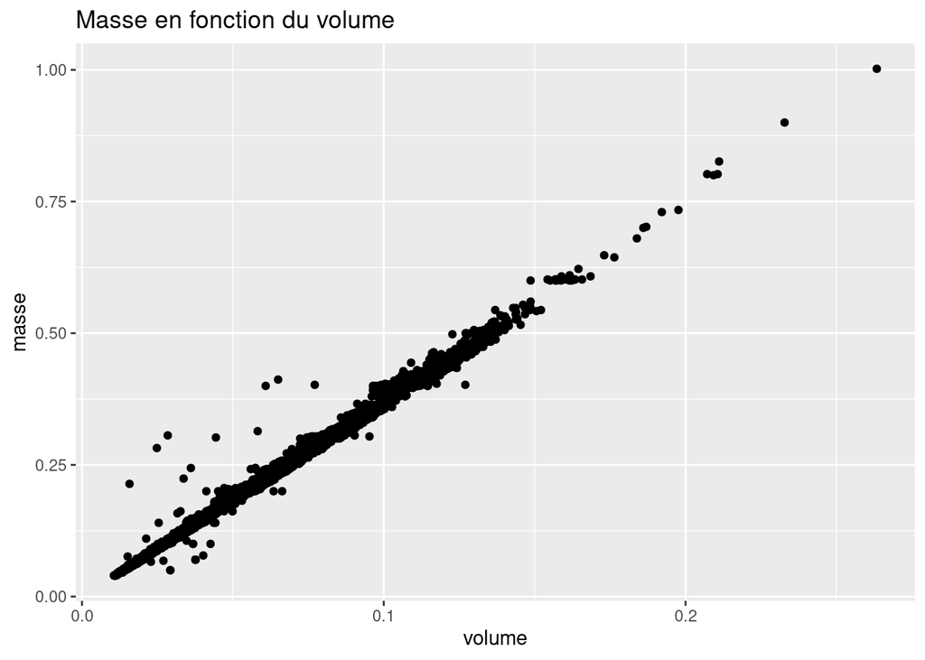

   ```r
   # Graphique :
   ggplot(diamants_bis) +
     aes(x=volume, y=masse) +
     geom_point() +
     labs(title="Masse en fonction du volume")
   ```

2. Effectuez les lignes de code présentes dans le script. En vous aidant si besoin de la documentation de la fonction `lm`, commentez les valeurs de `beta_0` et `beta_1`. Quelle est la signification physique de `beta_1` ?

   ```r
   linear_reg <- lm(masse~volume, data=diamants_bis)
   beta_0 <- linear_reg$coefficients[1]
   beta_1 <- linear_reg$coefficients[2]

   paste("beta_0 =", round(beta_0,3), ", beta_1 =", round(beta_1,3))
   ```

   ```
   [1] "beta_0 = -0.001 , beta_1 = 3.714"
   ```

*Réponse :`beta_0` est l’ordonnée à l’origine de la droite de régression linéaire. Ici `beta_0` vaut (presque) zéro, puisqu’un volume nul implique nécessairement un poids nul. `beta_1` est le coefficient directeur de la droite de régression linéaire. Cependant, ici on peut aussi l’interpréter comme l’augmentation du poids (en gramme) du diamant quand son volume augmente de* $1$ centimètre cube. C’est la **masse volumique** du diamant, exprimé en gramme par centimètre cube. (La valeur théorique est de 3.52 g.cm$^{-3}$.)

## Exercice 3

### Moyenne pondérée et produit cumulé

1. Étant donné un vecteur $x = (x_1, x_2, x_3, \dots, x_n)$ et un vecteur de poids correspondant $w = (w_1, w_2, \dots, w_n)$, calculez, **sans utiliser de boucles** la moyenne pondérée :

$$\sum_{i=1}^n \frac{w_i}{\sum_{k=1}^n w_k} x_i,$$
pour l’exemple donné dans le script `Exercice3`.

```r
x <- sample(1:40, size=15, replace=TRUE)
w <- sample(2:12, size=15, replace=TRUE)

moy_ponderee <- sum(w*x)/sum(w)
```

2. Créez le vecteur suivant $(1, 3, 5, \dots, 51)$, puis, à partir du vecteur précédent, créez le vecteur suivant :
   $$\begin{pmatrix} 1, 1\times 3, 1 \times 3 \times 5, \dots, 1 \times 3 \times 5 \dots \times 51 \end{pmatrix}$$

   ```r
   x_impair <- seq(1,51, by=2)
   prod_cumules <- cumprod(x_impair)
   ```

**Note**

*La suite de cet exercice propose, à partir de la densité de la loi normale centrée réduite* $\mathcal{N}(0,1)$*, de calculer numériquement la fonction de répartition de cette loi, et de trouver numériquement le quantile d’ordre* $\alpha$*. Au fil des questions, vous pourrez vérifier vos calculs en comparant (via la fonction `all.equal`) vos résultats à ceux obtenus par les fonctions présentes d’origines dans R.*

### Densité d’une loi normale centrée réduite

Écrivez une fonction $\phi$ (notée `phi`) calculant, pour $x \in \mathbb{R}$, la **densité** de probabilité d’une loi normale centrée réduite évaluée au point $x$. Vérifiez que cette fonction appliquée au vecteur $(-5, -4, \dots, 4, 5)$ renvoie la même sortie que la fonction adéquate présente de base dans R (*cf* `?Normal`).

```r
# Densité d'une loi normale centrée réduite
phi <- function(x){
  1/sqrt(2*pi)*exp(-x^2/2)
}

# Vérification :
all.equal(phi(-5:5), dnorm(-5:5))
```

```
[1] TRUE
```

### Fonction de répartition : cas d’un seul réel

1. Soit $x \geq 0$. Écrivez une fonction $F$ calculant la fonction de **répartition** d’une loi normale centrée réduite évaluée au point $x$. Appuyez vous sur l’approximation suivante :
   $$F(x) \approx \frac{1}{2} + \phi(x) \sum_{n=0}^{50} \frac{x^{(2n+1)}}{1 \times 3 \times 5 \dots \times (2n+1) },$$

Attention, la somme commence pour $n=0$. De plus les termes de la somme ne font intervenir que les entiers impairs. Vérifiez sur un réel positif arbitraire que $F$ renvoie la même valeur que la fonction adéquate présente de base dans R.

```r
F <- function(x){
  0.5+phi(x)*sum(x^x_impair/prod_cumules)
}

# Vérification arbitraire :
all.equal(F(3.14), pnorm(3.14))
```

```
[1] TRUE
```

2. Ré-écrivez la fonction $F$ précédente pour qu’elle puisse maintenant s’appliquer à un réel négatif. Utilisez la propriété suivante de la fonction $F$ pour un réel $x$ négatif :

$$F(x) = 1 - F(-x)$$

Vérifiez sur un réel négatif arbitraire que $F$ renvoie la même valeur que la fonction adéquate présente de base dans R.

```r
F <- function(x){
  if (x >= 0) {
    0.5+phi(x)*sum(x^x_impair/prod_cumules)
  }
  else {
    0.5-phi(-x)*sum((-x)^x_impair/prod_cumules)
  }
}
# Vérification arbitraire :
all.equal(F(-3.14), pnorm(-3.14))
```

```
[1] TRUE
```

### Fonction de répartition : cas vectorisé

Reprenez les questions précédentes pour que $F$ puisse s’appliquer à un vecteur de réels positifs. On notera `F_vect` cette nouvelle fonction. Vérifiez que `F_vect` renvoie le même résultat que la fonction de base de R lorsque appliquée au vecteur $(-3, -2.5, -2, \dots, 2.5, 3)$.

```r
F_vect <- function(x){
  sapply(x, FUN=F)
}

# Vérification :
all.equal(F_vect(-3:3), pnorm(-3:3))
```

```
[1] TRUE
```

### Calcul d’un quantile par dichotomie

**Important**

**Si vous n’avez pas réussi à coder la fonction de répartition `F_vect` ou `F`, utilisez la fonction adéquate présente dans R.**

On dispose maintenant de :

- $\phi$ (`phi`) la densité d’une loi normale centrée réduite
- $F$ (`F_vect` ou `F`) sa fonction de répartition.

Soit $\alpha = 0.975$.

**Objectif**

On recherche le réel $t^{\star} \in \mathbb{R}$ tel que $F(t^{\star}) = \alpha$, i.e le quantile d’ordre $\alpha$.

Puisque numériquement `F(-6)` renvoie `0` et `F(6)` renvoie `1`, on cherche $t^{\star}$ dans l’intervalle $[a,b] = [-6,6]$.

**Méthode à appliquer**

On se fixe un $t$ initial quelconque, disons $t=0$. On va comparer $F(t)$ et $\alpha = F(t^\star)$. En utilisant le fait que $F$ est strictement croissante et continue, on a trois cas possibles :

- Si $\lvert F(t) - \alpha \rvert \leq \epsilon$ alors on a trouvé $t^{\star}$.
- Sinon, alors
  - soit $F(t) > \alpha$ et il faut alors regarder “à gauche de $t$”, c’est a dire sur l’intervalle $[a, t]$. On pose donc $b \leftarrow t$ et on ré-itère la procédure avec $t \leftarrow \frac{a+t}{2}$, c’est-à-dire avec un nouveau $b$ prenant la valeur $t$ et un nouveau $t$ prenant la valeur du milieu du segment $[a,t]$.
  - soit $F(t) < \alpha$ et il faut alors regarder “à droite de $t$”, c’est a dire sur l’intervalle $[t, b]$. On pose donc $a \leftarrow t$ et on ré-itère la procédure avec $t \leftarrow \frac{b+t}{2}$, c’est-à-dire avec un nouveau $a$ prenant la valeur $t$ et un nouveau $t$ prenant la valeur du milieu du segment $[t,b]$.

C’est la méthode de la **dichotomie**. Implémentez cette méthode pour trouver $t^{\star}$, et vérifiez que vous obtenez le même résultat qu’en utilisant la fonction adéquate présente de base dans R.

*Indication : On pourra utiliser une boucle `while` et des conditions `if ... else`*.

```r
# Calcul d'un quantile par dichotomie
# Ordre du quantile souhaité :
alpha <- 0.975

# Bornes initiales de l'intervalle :
a <- -6
b <- 6

# t initial :
t <- 0

# Précision :
eps <- 1e-8

# Variable de comptage permettant d'éviter une boucle infinie :
n_iter <- 0
n_max <- 1000

# Dichotomie :
while ((abs(F_vect(t)-alpha) > eps) & (n_iter < n_max)){
  if ((F_vect(t)-alpha)>0){
    b <- t
    t <- (a+b)/2

  }
  else{
    a <- t
    t <- (a+b)/2
  }
  n_iter <- n_iter + 1
}

# Vérification :
all.equal(pnorm(t), alpha)
```

```
[1] TRUE
```